# 股票数据机器学习分类模型示例

本 Notebook 使用 `model_data_stock .csv` 建立二分类模型，并比较逻辑回归、决策树、随机森林与 K 近邻（KNN）的样本外表现。

数据严格按照日期划分：前三个季度为训练集，2022-03-31 为验证集，2022-06-30 为测试集。这样可以避免随机切分把未来数据泄漏到训练阶段。

> 注意：当前数据文件没有提供 `Y` 的业务定义，因此本文只把 `Y=True` 称为“正类”，不将其解释为上涨、盈利或投资信号。

```python
# 若使用随项目保存的依赖目录，先将其加入 Python 搜索路径。
import sys
import os
from pathlib import Path

task_dir = Path.cwd() if Path.cwd().name == 'task5' else Path.cwd() / 'task5'
local_packages = task_dir / '.python_packages'
if local_packages.exists():
    sys.path.insert(0, str(local_packages.resolve()))

# 避免部分 Windows 环境无法识别物理核心数的无关警告。
os.environ.setdefault('LOKY_MAX_CPU_COUNT', '4')

import warnings
import numpy as np
import pandas as pd
import matplotlib.pyplot as plt
%matplotlib inline
from IPython.display import display

from sklearn.base import clone
from sklearn.pipeline import Pipeline
from sklearn.impute import SimpleImputer
from sklearn.preprocessing import StandardScaler
from sklearn.linear_model import LogisticRegression
from sklearn.tree import DecisionTreeClassifier
from sklearn.ensemble import RandomForestClassifier
from sklearn.neighbors import KNeighborsClassifier
from sklearn.metrics import (
    accuracy_score, precision_score, recall_score, f1_score,
    roc_auc_score, roc_curve, confusion_matrix, ConfusionMatrixDisplay
)

RANDOM_STATE = 42
pd.set_option('display.max_columns', 30)
plt.style.use('seaborn-v0_8-whitegrid')
warnings.filterwarnings('ignore', category=FutureWarning)

print('Python:', sys.version.split()[0])
print('pandas:', pd.__version__)
import sklearn
print('scikit-learn:', sklearn.__version__)
```

```
Python: 3.12.13
pandas: 3.0.1
scikit-learn: 1.9.0
```

## 1. 加载并检查数据

股票代码必须作为字符串读取，以保留 `000001` 等代码的前导零。

```python
data_path = task_dir.parent / 'model_data_stock .csv'
if not data_path.exists():
    raise FileNotFoundError(f'未找到数据文件：{data_path.resolve()}')

df = pd.read_csv(data_path, encoding='utf-8-sig', dtype={'Code': 'string'})
df['Date'] = pd.to_datetime(df['Date'], errors='raise')

# 兼容 CSV 将布尔值读成 bool 或字符串两种情况。
if pd.api.types.is_bool_dtype(df['Y']):
    df['Y'] = df['Y'].astype(int)
else:
    y_map = {'False': 0, 'True': 1, '0': 0, '1': 1}
    df['Y'] = df['Y'].astype(str).str.strip().map(y_map)

if df['Y'].isna().any():
    raise ValueError('Y 包含无法识别的类别；预期为 True/False 或 0/1。')
if df.duplicated(['Date', 'Code']).any():
    raise ValueError('Date + Code 存在重复记录，请先检查数据。')

print(f'数据形状：{df.shape[0]:,} 行 × {df.shape[1]} 列')
print(f'日期范围：{df.Date.min().date()} 至 {df.Date.max().date()}')
print(f'股票数量：{df.Code.nunique():,}')
print(f'缺失值总数：{int(df.isna().sum().sum()):,}')
display(df.head())

date_summary = (df.groupby('Date')['Y']
                  .agg(样本数='size', 正类数='sum', 正类比例='mean'))
display(date_summary.assign(正类比例=date_summary['正类比例'].map(lambda x: f'{x:.2%}')))
```

```
数据形状：20,772 行 × 20 列
日期范围：2021-06-30 至 2022-06-30
股票数量：4,281
缺失值总数：0
```

|  | Date | Code | 企业倍数(EV除EBITDA) | 市净率PB(MRQ) | 市现率PCF(现金净流量TTM) | 市现率PCF(经营现金流TTM) | 市盈率PE(TTM) | 市盈率PE(TTM,扣除非经常性损益) | 市销率PS(TTM) | 股息率(近12个月) | MV | 净利润同比增长率 | 净资产同比增长率 | 利润总额(同比增长率) | 基本每股收益(同比增长率) | 总资产同比增长率 | 现金净流量同比增长率 | 营业利润(同比增长率) | 营业总收入(同比增长率) | Y |
| --- | --- | --- | --- | --- | --- | --- | --- | --- | --- | --- | --- | --- | --- | --- | --- | --- | --- | --- | --- | --- |
| 0 | 2021-06-30 | 000001 | 178.031265 | 1.450284 | 4.158766 | -9.604662 | 14.386532 | 14.418192 | 2.788759 | 0.795756 | 4389.618696 | 28.549496 | 7.340985 | 27.0313 | 21.212121 | 13.040136 | 3.065010 | 26.9324 | 8.1095 | 0 |
| 1 | 2021-06-30 | 000002 | 4.087263 | 1.225560 | 12.789059 | 3.788184 | 6.656121 | 6.850769 | 0.637955 | 4.269690 | 2698.195472 | -13.181867 | 13.417901 | -16.5199 | -14.414414 | 8.241644 | -95.340285 | -17.2279 | 14.1862 | 0 |
| 2 | 2021-06-30 | 000004 | 43.451859 | 2.096619 | 46.748413 | 1845.349234 | 47.051819 | 48.211020 | 10.426417 | 0.680641 | 30.633767 | 193.215436 | 4.885155 | 93.9522 | 136.538462 | 5.093304 | -3.498717 | 92.2387 | 73.9161 | 1 |
| 3 | 2021-06-30 | 000005 | -6.016503 | 1.594176 | -140.760010 | 33.437268 | -5.557283 | -4.482084 | 4.958022 | 0.987982 | 19.900493 | 673.411428 | -11.424587 | 701.1840 | 700.657895 | -18.248636 | 48.889779 | 120.7927 | 22.7985 | 1 |
| 4 | 2021-06-30 | 000006 | 8.856827 | 0.885989 | 7.312974 | 17.339335 | 6.722733 | 7.026851 | 2.113051 | 3.852295 | 67.634752 | 75.185870 | 11.547872 | 65.4533 | 78.460583 | 25.341466 | -14.232979 | 60.0630 | 22.6193 | 0 |

| Date | 样本数 | 正类数 | 正类比例 |
| --- | --- | --- | --- |
| 2021-06-30 | 4011 | 1809 | 45.10% |
| 2021-09-30 | 4098 | 2868 | 69.99% |
| 2021-12-31 | 4173 | 1025 | 24.56% |
| 2022-03-31 | 4228 | 1880 | 44.47% |
| 2022-06-30 | 4262 | 807 | 18.93% |

## 2. 按日期设置训练集、验证集和测试集

- 训练集：2021-06-30、2021-09-30、2021-12-31
- 验证集：2022-03-31
- 测试集：2022-06-30

`Date`、`Code` 是标识字段，不作为模型输入。所有填补和标准化参数仅在训练集上拟合。

```python
train_dates = pd.to_datetime(['2021-06-30', '2021-09-30', '2021-12-31'])
valid_date = pd.Timestamp('2022-03-31')
test_date = pd.Timestamp('2022-06-30')

train_df = df[df['Date'].isin(train_dates)].copy()
valid_df = df[df['Date'].eq(valid_date)].copy()
test_df = df[df['Date'].eq(test_date)].copy()

if min(len(train_df), len(valid_df), len(test_df)) == 0:
    raise ValueError('至少一个数据集为空，请检查日期设置。')
if not (train_df.Date.max() < valid_df.Date.min() < test_df.Date.min()):
    raise ValueError('时间顺序不正确，存在潜在数据泄漏。')

feature_cols = [c for c in df.columns if c not in ['Date', 'Code', 'Y']]
for c in feature_cols:
    train_df[c] = pd.to_numeric(train_df[c], errors='coerce')
    valid_df[c] = pd.to_numeric(valid_df[c], errors='coerce')
    test_df[c] = pd.to_numeric(test_df[c], errors='coerce')

X_train, y_train = train_df[feature_cols], train_df['Y']
X_valid, y_valid = valid_df[feature_cols], valid_df['Y']
X_test, y_test = test_df[feature_cols], test_df['Y']

split_summary = pd.DataFrame({
    '样本数': [len(y_train), len(y_valid), len(y_test)],
    '正类数': [y_train.sum(), y_valid.sum(), y_test.sum()],
    '正类比例': [y_train.mean(), y_valid.mean(), y_test.mean()]
}, index=['训练集', '验证集', '测试集'])
display(split_summary.assign(正类比例=split_summary['正类比例'].map(lambda x: f'{x:.2%}')))
print(f'模型特征数：{len(feature_cols)}')
```

|  | 样本数 | 正类数 | 正类比例 |
| --- | --- | --- | --- |
| 训练集 | 12282 | 5702 | 46.43% |
| 验证集 | 4228 | 1880 | 44.47% |
| 测试集 | 4262 | 807 | 18.93% |

```
模型特征数：17
```

## 3. 构建并训练四种分类模型

逻辑回归和 KNN 对变量尺度敏感，因此使用中位数填补和标准化；决策树和随机森林仅进行中位数填补。这里使用固定的教学型参数，后续可只利用训练集和验证集进行调参。

```python
scaled_preprocess = [
    ('imputer', SimpleImputer(strategy='median')),
    ('scaler', StandardScaler())
]
tree_preprocess = [('imputer', SimpleImputer(strategy='median'))]

models = {
    'Logistic Regression': Pipeline(scaled_preprocess + [
        ('model', LogisticRegression(max_iter=2000, class_weight='balanced', random_state=RANDOM_STATE))
    ]),
    'Decision Tree': Pipeline(tree_preprocess + [
        ('model', DecisionTreeClassifier(
            max_depth=6, min_samples_leaf=30, class_weight='balanced',
            random_state=RANDOM_STATE
        ))
    ]),
    'Random Forest': Pipeline(tree_preprocess + [
        ('model', RandomForestClassifier(
            n_estimators=300, max_depth=10, min_samples_leaf=10,
            max_features='sqrt', class_weight='balanced',
            random_state=RANDOM_STATE, n_jobs=-1
        ))
    ]),
    'KNN': Pipeline(scaled_preprocess + [
        ('model', KNeighborsClassifier(n_neighbors=25, weights='distance', n_jobs=-1))
    ])
}

fitted_models = {}
for name, model in models.items():
    print(f'正在训练：{name}')
    fitted_models[name] = clone(model).fit(X_train, y_train)
print('四个模型训练完成。')
```

```
正在训练：Logistic Regression
```

```
正在训练：Decision Tree
正在训练：Random Forest
```

```
正在训练：KNN
四个模型训练完成。
```

## 4. 模型评估与 AUC

AUC 是 ROC 曲线下的面积，衡量模型将正类排在负类之前的能力。AUC=0.5 接近随机排序，越接近 1 越好。这里同时报告 Accuracy、Precision、Recall 和 F1，避免只看单一指标。

```python
def evaluate_models(fitted, X, y, dataset_name):
    rows = []
    probabilities = {}
    for name, model in fitted.items():
        prob = model.predict_proba(X)[:, 1]
        pred = (prob >= 0.5).astype(int)
        probabilities[name] = prob
        rows.append({
            '数据集': dataset_name,
            '模型': name,
            'AUC': roc_auc_score(y, prob),
            'Accuracy': accuracy_score(y, pred),
            'Precision': precision_score(y, pred, zero_division=0),
            'Recall': recall_score(y, pred, zero_division=0),
            'F1': f1_score(y, pred, zero_division=0),
        })
    return pd.DataFrame(rows), probabilities

valid_metrics, valid_probabilities = evaluate_models(
    fitted_models, X_valid, y_valid, 'Validation (2022-03-31)'
)
test_metrics, test_probabilities = evaluate_models(
    fitted_models, X_test, y_test, 'Test (2022-06-30)'
)
metrics = pd.concat([valid_metrics, test_metrics], ignore_index=True)
display(metrics.round({
    'AUC': 4, 'Accuracy': 4, 'Precision': 4, 'Recall': 4, 'F1': 4
}))

print('测试集 AUC：')
display(test_metrics[['模型', 'AUC']].sort_values('AUC', ascending=False).round({'AUC': 4}))
```

|  | 数据集 | 模型 | AUC | Accuracy | Precision | Recall | F1 |
| --- | --- | --- | --- | --- | --- | --- | --- |
| 0 | Validation (2022-03-31) | Logistic Regression | 0.4781 | 0.4638 | 0.4262 | 0.5947 | 0.4966 |
| 1 | Validation (2022-03-31) | Decision Tree | 0.5068 | 0.5211 | 0.4607 | 0.4516 | 0.4561 |
| 2 | Validation (2022-03-31) | Random Forest | 0.5215 | 0.5229 | 0.4626 | 0.4505 | 0.4565 |
| 3 | Validation (2022-03-31) | KNN | 0.4972 | 0.5099 | 0.4427 | 0.3941 | 0.4170 |
| 4 | Test (2022-06-30) | Logistic Regression | 0.5462 | 0.4423 | 0.2051 | 0.6766 | 0.3148 |
| 5 | Test (2022-06-30) | Decision Tree | 0.5820 | 0.5655 | 0.2266 | 0.5366 | 0.3186 |
| 6 | Test (2022-06-30) | Random Forest | 0.5960 | 0.5723 | 0.2326 | 0.5477 | 0.3266 |
| 7 | Test (2022-06-30) | KNN | 0.5518 | 0.5943 | 0.2230 | 0.4597 | 0.3003 |

```
测试集 AUC：
```

|  | 模型 | AUC |
| --- | --- | --- |
| 2 | Random Forest | 0.5960 |
| 1 | Decision Tree | 0.5820 |
| 3 | KNN | 0.5518 |
| 0 | Logistic Regression | 0.5462 |

## 5. 绘制测试集 ROC 曲线

ROC 曲线横轴是假正率（FPR），纵轴是真正率（TPR）。灰色对角线表示随机分类器。曲线越靠近左上角、AUC 越高，模型的整体排序能力越强。

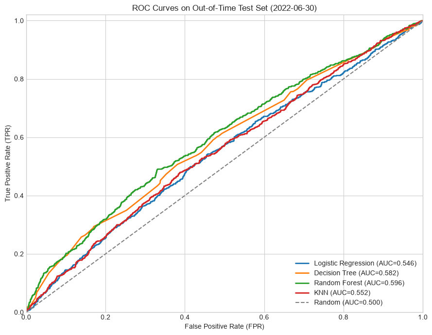

```
ROC 图已保存：E:\课程\光华BA\量化金融\openworkshop\task5\roc_curves_test.png
```

```python
fig, ax = plt.subplots(figsize=(9, 7))
for name, prob in test_probabilities.items():
    fpr, tpr, _ = roc_curve(y_test, prob)
    auc_value = roc_auc_score(y_test, prob)
    ax.plot(fpr, tpr, linewidth=2, label=f'{name} (AUC={auc_value:.3f})')

ax.plot([0, 1], [0, 1], linestyle='--', color='gray', label='Random (AUC=0.500)')
ax.set_xlabel('False Positive Rate (FPR)')
ax.set_ylabel('True Positive Rate (TPR)')
ax.set_title('ROC Curves on Out-of-Time Test Set (2022-06-30)')
ax.set_xlim(0, 1)
ax.set_ylim(0, 1.02)
ax.legend(loc='lower right')
fig.tight_layout()
roc_path = task_dir / 'roc_curves_test.png'
fig.savefig(roc_path, dpi=160, bbox_inches='tight')
plt.show()
print(f'ROC 图已保存：{roc_path.resolve()}')
```

## 6. 混淆矩阵（阈值 0.5）

混淆矩阵展示 TN、FP、FN、TP。阈值 0.5 只是默认值；实际应用中应根据误报和漏报成本在验证集上选择阈值，再固定到测试集。

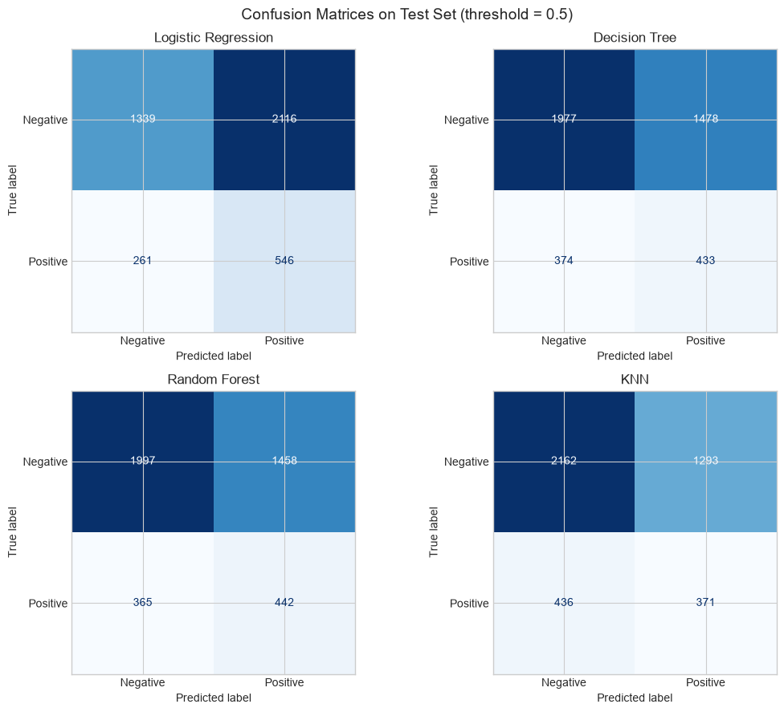

```python
fig, axes = plt.subplots(2, 2, figsize=(11, 9))
for ax, (name, prob) in zip(axes.ravel(), test_probabilities.items()):
    pred = (prob >= 0.5).astype(int)
    cm = confusion_matrix(y_test, pred)
    ConfusionMatrixDisplay(cm, display_labels=['Negative', 'Positive']).plot(
        ax=ax, colorbar=False, cmap='Blues'
    )
    ax.set_title(name)
fig.suptitle('Confusion Matrices on Test Set (threshold = 0.5)', fontsize=14)
fig.tight_layout()
plt.show()
```

## 7. 使用说明与局限性

1. 验证集用于比较模型和调整参数；测试集只用于最终样本外评价。
2. 本数据只有 5 个季度截面，测试结果可能对市场阶段非常敏感。
3. 不同季度的正类比例变化明显，因此 AUC 应与 Precision、Recall、F1 和混淆矩阵共同判断。
4. 在用于投资研究前，必须确认 `Y` 的定义、预测期限，以及所有财务特征在当时是否已经公开，排除前视偏差。
5. 本示例没有考虑交易成本、滑点、停牌、涨跌停和组合构建，因此不能直接作为交易策略。